# MAT213 Project #2

Bjorn Melin

3/5/2019

## **Link to Original Data Tables Source:**

[https://en.wikipedia.org/wiki/List_of_Olympic_medalists_in_freestyle_skiing]

## **Explanation of Website:**

The reason I chose the website and the tables I did is because I love to ski and thought that it would be fun to work on a project involving data that I am interested in. This website is titled “List of Olympic metalists in freestyle skiing” and includes many tables showing which athlete won each metal and their country for different events in freestyle skiing over the course of many olympic games. It also shows athlete metal leaders, their total metal counts, and which country they are from. For this project, I will focus on the “Aerials” freestyle skiing event. I will be using the tables containing aerial event metal data for men and women. Combining them in such a way that I am able to create a meaningful data visualization and draw a meaningful conclusion.

## **Questions to be Answered:**

How do the metal counts for each country from 1994-2018 for each type of metal compare to one another? What country has won the highest number of metals for each type of metal (gold, silver, and bronze).

## **Original Tables:**

Mens Aerials

| Games | Gold | Silver | Bronze |
| --- | --- | --- | --- |
| 1994 Lillehammerdetails | Andreas Schönbächler Switzerland | Philippe LaRoche Canada | Lloyd Langlois Canada |
| 1998 Naganodetails | Eric Bergoust United States | Sébastien Foucras France | Dmitri Dashinski Belarus |
| 2002 Salt Lake Citydetails | Aleš Valenta Czech Republic | Joe Pack United States | Aleksei Grishin Belarus |
| 2006 Turindetails | Han Xiaopeng China | Dmitri Dashinski Belarus | Vladimir Lebedev Russia |
| 2010 Vancouverdetails | Aleksei Grishin Belarus | Jeret Peterson United States | Liu Zhongqing China |
| 2014 Sochidetails | Anton Kushnir Belarus | David Morris Australia | Jia Zongyang China |
| 2018 Pyeongchangdetails | Oleksandr Abramenko Ukraine | Jia Zongyang China | Ilya Burov Olympic Athletes from Russia |

Womens Aerials

| Games | Gold | Silver | Bronze |
| --- | --- | --- | --- |
| 1994 Lillehammerdetails | Lina Cheryazova Uzbekistan | Marie Lindgren Sweden | Hilde Synnøve Lid Norway |
| 1998 Naganodetails | Nikki Stone United States | Xu Nannan China | Colette Brand Switzerland |
| 2002 Salt Lake Citydetails | Alisa Camplin Australia | Veronica Brenner Canada | Deidra Dionne Canada |
| 2006 Turindetails | Evelyne Leu Switzerland | Li Nina China | Alisa Camplin Australia |
| 2010 Vancouverdetails | Lydia Lassila Australia | Li Nina China | Guo Xinxin China |
| 2014 Sochidetails | Alla Tsuper Belarus | Xu Mengtao China | Lydia Lassila Australia |
| 2018 Pyeongchangdetails | Hanna Huskova Belarus | Zhang Xin China | Kong Fanyu China |

## **Table After Merging the Two Input Tables:**

Merged Men/Women Aerials

| Games | Gold | Silver | Bronze | Gender |
| --- | --- | --- | --- | --- |
| 1994 Lillehammer | Andreas Schönbächler Switzerland | Philippe LaRoche Canada | Lloyd Langlois Canada | Male |
| 1994 Lillehammer | Lina Cheryazova Uzbekistan | Marie Lindgren Sweden | Hilde Synnøve Lid Norway | Female |
| 1998 Nagano | Eric Bergoust United States | Sébastien Foucras France | Dmitri Dashinski Belarus | Male |
| 1998 Nagano | Nikki Stone United States | Xu Nannan China | Colette Brand Switzerland | Female |
| 2002 Salt Lake City | Aleš Valenta Czech Republic | Joe Pack United States | Aleksei Grishin Belarus | Male |
| 2002 Salt Lake City | Alisa Camplin Australia | Veronica Brenner Canada | Deidra Dionne Canada | Female |
| 2006 Turin | Han Xiaopeng China | Dmitri Dashinski Belarus | Vladimir Lebedev Russia | Male |
| 2006 Turin | Evelyne Leu Switzerland | Li Nina China | Alisa Camplin Australia | Female |
| 2010 Vancouver | Aleksei Grishin Belarus | Jeret Peterson United States | Liu Zhongqing China | Male |
| 2010 Vancouver | Lydia Lassila Australia | Li Nina China | Guo Xinxin China | Female |
| 2014 Sochi | Anton Kushnir Belarus | David Morris Australia | Jia Zongyang China | Male |
| 2014 Sochi | Alla Tsuper Belarus | Xu Mengtao China | Lydia Lassila Australia | Female |
| 2018 Pyeongchang | Oleksandr Abramenko Ukraine | Jia Zongyang China | Ilya Burov Olympic Athletes from Russia | Male |
| 2018 Pyeongchang | Hanna Huskova Belarus | Zhang Xin China | Kong Fanyu China | Female |

## **Two Tables Showing Desired Results After Tidying the Merged Table:**

#### **First Table (Best Representation to be Used in a Plot):**

Metal Types/Counts Per Country (Representation 1)

| country | metal_count | Metal |
| --- | --- | --- |
| Belarus | 4 | Gold |
| Australia | 2 | Gold |
| Switzerland | 2 | Gold |
| United States | 2 | Gold |
| China | 1 | Gold |
| Czech Republic | 1 | Gold |
| Ukraine | 1 | Gold |
| Uzbekistan | 1 | Gold |
| China | 6 | Silver |
| Canada | 2 | Silver |
| United States | 2 | Silver |
| Australia | 1 | Silver |
| Belarus | 1 | Silver |
| France | 1 | Silver |
| Sweden | 1 | Silver |
| China | 4 | Bronze |
| Australia | 2 | Bronze |
| Belarus | 2 | Bronze |
| Canada | 2 | Bronze |
| Lid Norway | 1 | Bronze |
| Olympic Athletes from Russia | 1 | Bronze |
| Russia | 1 | Bronze |
| Switzerland | 1 | Bronze |

#### Second Table (Best Table Representation of Data):

Metal Types/Counts Per Country (Representation 2)

| country | Gold | Silver | Bronze |
| --- | --- | --- | --- |
| Belarus | 4 | 1 | 2 |
| United States | 2 | 2 | 0 |
| Australia | 2 | 1 | 2 |
| Switzerland | 2 | 0 | 1 |
| China | 1 | 6 | 4 |
| Czech Republic | 1 | 0 | 0 |
| Ukraine | 1 | 0 | 0 |
| Uzbekistan | 1 | 0 | 0 |
| Canada | 0 | 2 | 2 |
| France | 0 | 1 | 0 |
| Sweden | 0 | 1 | 0 |
| Lid Norway | 0 | 0 | 1 |
| Olympic Athletes from Russia | 0 | 0 | 1 |
| Russia | 0 | 0 | 1 |

## **Meaningful Data Graphic that Addresses the Questions:**

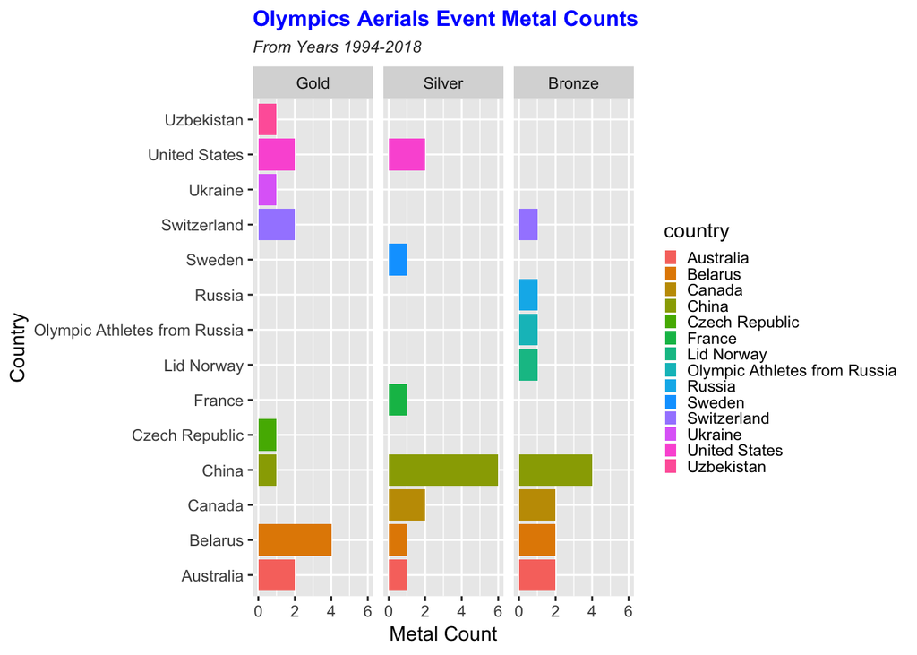

## **Narrative Description of Data Graphic:**

There is one aspect about my final merged tables and final graphic that is important to mention. This being that the country with the name “Olympic Athletes from Russia” is not really seperate country, it is really just the same as the country “Russia”. The reason why it is listed seperately and with a different name involves a doping scandal among Russian olympic athletes in 2018. This doping scandal led to the Russian Olympic Committee being suspended for the 2018 winter olympic games and is why those participating in the 2018 games could not compete for the country of Russia directly. For this project, I decided to keep “Russia” and “Olympic Athletes from Russia” as seperate countries as technically speaking, they are in fact different. A link for further information on this topic here [link](https://en.wikipedia.org/wiki/Olympic_Athletes_from_Russia_at_the_2018_Winter_Olympics).

There are many possible questions that could be answered and many graphics that could be created from this dataset. As for the reason why I chose the questions that I did, I believe that many of the possible questions that could have been asked would have been too similar to what the original tables show or would have answers that could be found by simple observations on the original tables. Some examples of questions I thought about of this sort are how many metals each country won per olympics? What country has won the most metals for this event? Who has won the most overall metals in this event? All of these questions would be great but after dissecting the website containing the original tables, I realized that there had already been other tables created which show answers for many of these questions. Also, many of these questions could be easily answered by a quick observation of the two original tables I chose. These factors all played a role in why I landed on the questions that I did for this project. I believe that my questions are complex in that they require modifications to be made on the original tables and a graphic to be created in order to quickly and clearly obtain the answers desired.